# MLB Ballpark Factors

Aidan Judge

# MLB Ballpark Factors

## Overview

I have always heard about Coors Field in Denver Colorado having the most homeruns because of the altitude of the ballpark and how that makes it a hitter’s field. In 2017, my favorite baseball team, the New York Yankees, had two of the leagues leading hitters in the homerun categorie. These two players, Aaron Judge, and Gary Sanchez, had 52 and 33 homeruns, respectively, due in large part to the “short porch” at Yankee stadium. This short porch refers to the 314-foot wall in right field that is relatively short and makes the park a “hitter’s park.” For this project, I amalgamated data on batting statistics sorted by individual ballparks from 2013-2017 and then combined this with the average distance from homeplate to the homerun wall for each park as well as city elevation data for each MLB city. What I want to find out is how elevation and park size play a roll in creating a “hitter’s park.”

## Data dictionary

Here is a data dictionary for the MLB Data dataset:

- **year**: Year of the Data
- **rank**: Rank
- **park_name**: MLB Park Name
- **runs**: Runs Scored Factor
- **hr**: Home Run Factor
- **h**: Hits Factor
- **doubles**: Doubles Factor
- **triples**: Triples Factor
- **bb**: Walks Factor
- **elevation**: Elevation
- **avg_wall_distance**: Average Wall Distance
- **abbrev**: Abbreviated Name

Which can be read in as follows:

```r
mlbdata <- read_csv("https://raw.githubusercontent.com/urstats/stat209-s18-AidanJudge/master/Data_for_Assignment_A.csv")
mlbdata
```

[output not shown]

## Exploratory Analysis

In the first graph below, I wanted to see the effects of the elevation of all of the 30 MLB teams on the success of teams’ offense in general. The MLB releases park specific data on different ballpark factors. In the first graph, I plot the “runs factor” which compares the rate of stats at home vs. the rate of stats on the road for how many runs each team scores. This negates the effect of the actual quality of the team across different years (obviously the Yankees score more runs in years they win the World Series) and only compares the individual stats (runs, hits, homeruns, doubles, and triples) as a ratio of how many each team gets while playing at home versus on the road to isolate the effects of their ballparks.

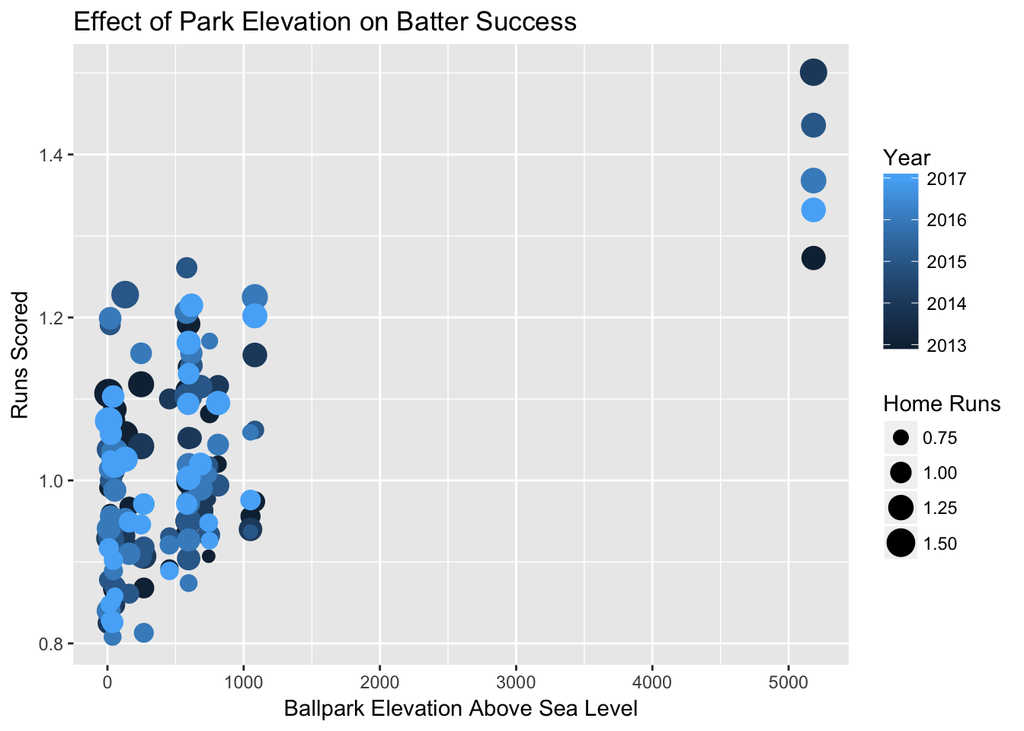

What I find in the first exhibit, “Effect of Park Elevation on Batter Success,” is that the more elevated the team’s ballpark is, the more runs they score at home as a multiple of how many they score on the road. In the second exhibit, “Effects of Park Size on Batter Success,” I was trying to get a better understanding of the “short porch” effect that announcers always talk about with some smaller fields like Yankee Stadium and Fenway park.

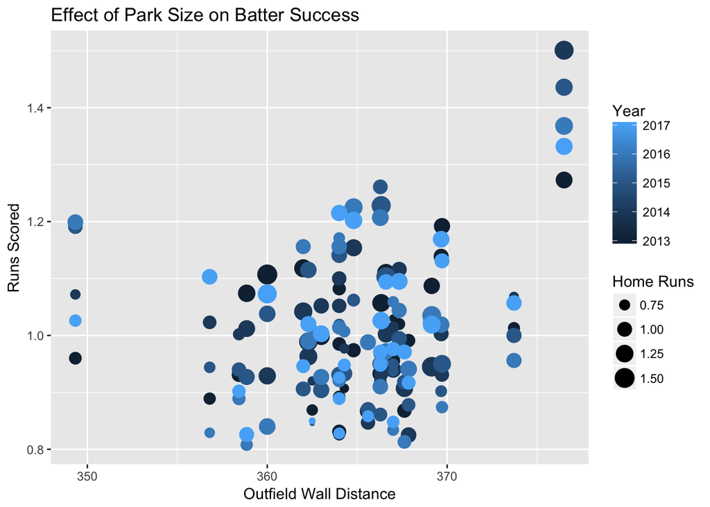

I ultimately did not see as much of a correlation for the average distance of the outfield walls on a team’s offensive success as there is with the park’s elevation.

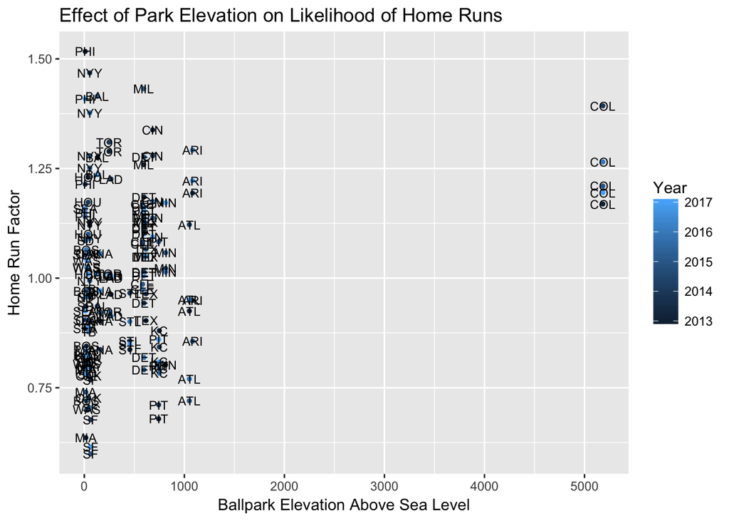

## Conclusion

I was interested to confirm what I have always heard about teams playing better at home when they are located in cities at higher elevations. It was rather surprising to find that there was not a clear relationship between the average distance of the park’s outfield and the runs scored factor. If I were to do further analysis, I would look into adding a variable for each park’s shortest outfield wall, rather than just the average distance, because I think taking the average might have made all of the parks seem more similar to one another in size than they might seem to batters.

## References

###### http://www.espn.com/mlb/stats/parkfactor/_/year/2017

###### http://baseballjudgments.tripod.com/id62.html

###### http://www.andrewclem.com/Baseball/Dimensions.html